# space{3.5in}Analysis of Accidental Drug Related Deaths

## Patterns in Drug consumption over Years

```r
#only plotting top 5 chemicals
#df_chem <- read.csv("data.csv",na.strings=c("","NA"))
df_chem<-df_main
chemical_cols <- c("Heroin","Cocaine","Fentanyl" ,"FentanylAnalogue", "Oxycodone" ,"Oxymorphone" ,"Ethanol","Hydrocodone","Benzodiazepine","Methadone", "Amphet","Tramad","Morphine_NotHeroin","Hydromorphone")

    df_rca <- subset(df_chem, select=c('Date','DescriptionofInjury', chemical_cols))
    all_chemicals <- c()

    for (row in 1:nrow(df_rca)) {
      chemical_list <-  ''
      chemical_count <- 0
      for (chemical in chemical_cols){
        val = df_rca[row, chemical]
        if (!is.na(val)){
          chemical_list <- paste(chemical_list, chemical, sep=',')
          chemical_count <- chemical_count+1
          all_chemicals <- c(all_chemicals, chemical)
        }
      }
    }
df_chem<- as.data.frame(table(all_chemicals))
df_chem<-df_chem[with(df_chem, order(-df_chem$Freq)), ]
head(df_chem,5)
```

|  | all_chemicals | Freq |
| --- | --- | --- |
| 7 | Heroin | 2529 |
| 5 | Fentanyl | 2232 |
| 3 | Cocaine | 1521 |
| 2 | Benzodiazepine | 1343 |
| 4 | Ethanol | 1247 |

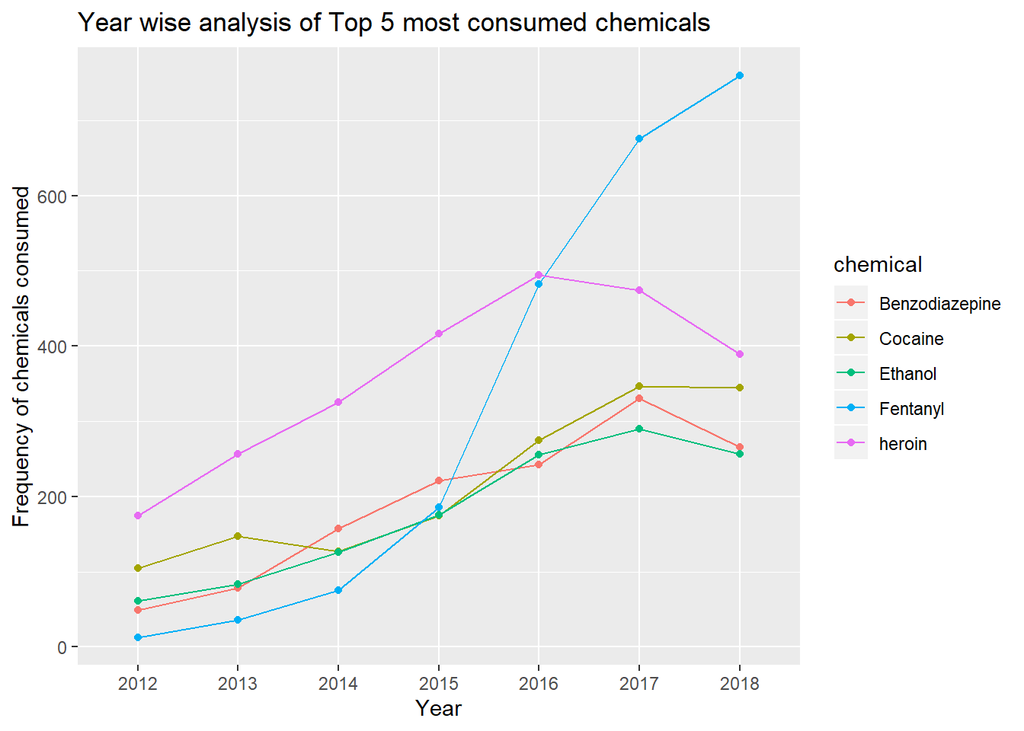

```r
he<-temp%>%group_by(yr=fct_explicit_na(year),Heroin)%>%summarise(cnt=n())%>%filter(Heroin=='Y')
he$Heroin<-"heroin"
he<-he%>%rename(chemical=Heroin)
co<-temp%>%group_by(yr=fct_explicit_na(year),Cocaine)%>%summarise(cnt=n())%>%filter(Cocaine=='Y')
co<-co[1:7,]
co$Cocaine<-"Cocaine"
co<-co%>%rename(chemical=Cocaine)
fe<-temp%>%group_by(yr=fct_explicit_na(year),Fentanyl)%>%summarise(cnt=n())%>%filter(Fentanyl=='Y')
fe$Fentanyl<-"Fentanyl"
fe<-fe%>%rename(chemical=Fentanyl)
be<-temp%>%group_by(yr=fct_explicit_na(year),Benzodiazepine)%>%summarise(cnt=n())%>%filter(Benzodiazepine=='Y')
be$Benzodiazepine<-"Benzodiazepine"
be<-be%>%rename(chemical=Benzodiazepine)
eth<-temp%>%group_by(yr=fct_explicit_na(year),Ethanol)%>%summarise(cnt=n())%>%filter(Ethanol=='Y')
eth$Ethanol<-"Ethanol"
eth<-eth%>%rename(chemical=Ethanol)
df1<-dplyr::bind_rows(he,fe,co,be,eth)
df1%>%ggplot(aes(x=yr,y=cnt,color=chemical,group=chemical))+geom_line()+geom_point()+xlab("Year")+ylab("Frequency of chemicals consumed")+ggtitle("Year wise analysis of Top 5 most consumed chemicals")
```

# Causal Diagnosis of Drug Abuse

We want to analyze the drug abuse cases in order to highlight the major contributing factors. We will investigate the underlying root causes: major chemicals consumed, type of injuries people suffered from. From this investigation, we are trying to find the most common checmicals found in the drug abuse cases. Moreover, we will inquire the forms of drug abuse such as ingested pills, alcohol, abuse of medication, substance abuse etc. And we will try to attribute the categories contributing to the most of the cases.

## Derived Metric Calculation

In medical diagnosis of durg abuse cases, there are generally 14 types of chemicals found - Heroin, Cocaine, Fentanyl, FentanylAnalogue, Oxycodone, Oxymorphone, Ethanol, Hydrocodone, Benzodiazepine, Methadone, Amphet, Tramad, Morphine_NotHeroin, Hydromorphone. In thsi section we are calculating the derived metrics as “diagnosed_chemicals” and “diagnosed_chemicals_count”. Metric “diagnosed_chemicals” represents the list of chemicals found in each case of drug abuse, eesentially in each row in the dataframe. Similarly, metric “diagnosed_chemicals_count” denotes the number of checmical found in each drug abuse case out of exaustive list of 14 chemicals mentioned here. Both of these derived metrics will be explored further in the below sections.

```r
#df_main <- read.csv("Accidental_Drug_Related_Deaths_2012-2018.csv",na.strings=c("","NA"))

# List of chemicals
chemical_cols <- c("Heroin","Cocaine","Fentanyl" ,"FentanylAnalogue", "Oxycodone" ,"Oxymorphone" ,"Ethanol","Hydrocodone","Benzodiazepine","Methadone", "Amphet","Tramad","Morphine_NotHeroin","Hydromorphone")

# Subset relevant columns for root cause analysis
df_rca <- subset(df_main, select=c('Date','DescriptionofInjury', chemical_cols))

# Adding diagnosed chemical list for each drug abuse case
diagnosed_chemicals = c()
count_diagnosed_chemicals = c()
all_chemicals <- c()

for (row in 1:nrow(df_rca)) {
  chemical_list <-  ''
  chemical_count <- 0
  for (chemical in chemical_cols){
    val = df_rca[row, chemical]
    if (!is.na(val)){
      chemical_list <- paste(chemical_list, chemical, sep=',')
      chemical_count <- chemical_count+1
      all_chemicals <- c(all_chemicals, chemical)
    }
  }
  diagnosed_chemicals <- c(diagnosed_chemicals, substr(chemical_list, 2, nchar(chemical_list)))
  count_diagnosed_chemicals <- c(count_diagnosed_chemicals, chemical_count)
}
df_rca$Diagnosed_Chemicals <- diagnosed_chemicals
df_rca$diagnosed_chemicals_count <- count_diagnosed_chemicals

head(df_rca[, c('Diagnosed_Chemicals', 'diagnosed_chemicals_count')])
```

|  | Diagnosed_Chemicals | diagnosed_chemicals_count |
| --- | --- | --- |
| 1 | Fentanyl,Hydrocodone,Benzodiazepine | 3 |
| 2 | Cocaine | 1 |
| 3 | Heroin,Cocaine | 2 |
| 4 | Heroin,Fentanyl | 2 |
| 5 | Fentanyl | 1 |
| 6 | Heroin | 1 |

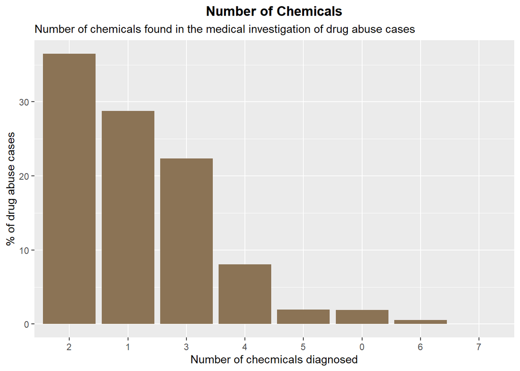

```r
# histogram of number of chemicals in different drug abuse caess
total = nrow(df_rca)
temp_df <- df_rca %>% group_by(diagnosed_chemicals_count) %>% summarise(Count = n()*100/total)
ggplot(temp_df, aes(x = reorder(diagnosed_chemicals_count, -Count), y=Count)) +
  geom_histogram(stat="identity", fill = "burlywood4") +
  ggtitle("Number of Chemicals",
          subtitle = "Number of chemicals found in the medical investigation of drug abuse cases") +
  labs(x = "Number of checmicals diagnosed", y = "% of drug abuse cases") +
  theme(plot.title = element_text(face = "bold"))  +
  theme(plot.caption = element_text(color = "grey68"))+
  theme(plot.title = element_text(hjust = 0.5))
```

## Distribution of 14 chemicals in Drug abuse Cases

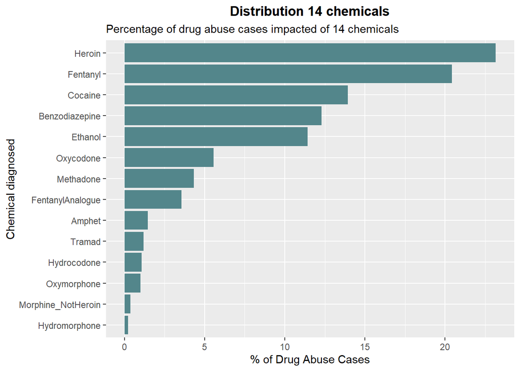

```r
# Contribution of chemicals in different cases
temp_df <- data.frame('Drug_Composition'=all_chemicals)
total = nrow(temp_df)
temp_df <- temp_df %>% group_by(Drug_Composition) %>% summarise(Count = n()*100/total)

ggplot(temp_df, aes(x = reorder(Drug_Composition, Count), y=Count)) +
  geom_histogram(stat="identity", fill = "cadetblue4") +
  coord_flip() +
  ggtitle("Distribution 14 chemicals",
          subtitle = "Percentage of drug abuse cases impacted of 14 chemicals") +
  labs(x = "Chemical diagnosed", y = "% of Drug Abuse Cases") +
  theme(plot.title = element_text(face = "bold"))  +
  theme(plot.caption = element_text(color = "grey68"))+
  theme(plot.title = element_text(hjust = 0.5))
```

## Associatio mining aming 14 Chemicals

We want to further mine the association between these 14 chemicals - which combination of chemicals occur most frequently. Among all combinations occured together, Heroin with Fentanyl(5%) and Heroin with Cocaine(4.7%) and Heroin with Ethanol(3.3%) were the frequently found combinations. Hence these two are popular associations discovered. As we can notice here, Heroine is present in all the popular associations as Heroine is concluded to be most frequently found chemicals.

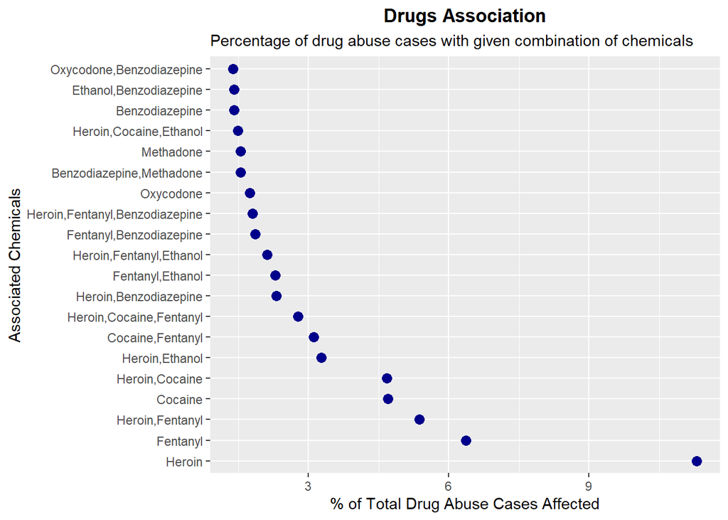

```r
# Contribution of chemicals in different cases
temp_df <- df_rca[df_rca$Diagnosed_Chemicals>1,]
temp_df <- data.frame(temp_df  %>%
                group_by(Diagnosed_Chemicals) %>%
                summarise(Freq=n()) %>%
                mutate(Perc_Cases=100*(Freq/nrow(df_rca))))
temp_df <- temp_df[temp_df$Freq>1,]

#temp_df <- temp_df[,temp_df[order('Perc_Cases', 'Freq','diagnosed_chemicals')]]
temp_df <- temp_df[order(temp_df[,'Perc_Cases'] ),]

# Top 20 combinations occured together
temp_df <- tail(temp_df, 20)


ggplot(temp_df, aes(x = reorder(Diagnosed_Chemicals, -Freq), y=Perc_Cases)) +
  geom_point(color='darkblue', size=3) +
  ggtitle("Drugs Association",
          subtitle = "Percentage of drug abuse cases with given combination of chemicals") +
    coord_flip() +
  labs(x = "Associated Chemicals", y = "% of Total Drug Abuse Cases Affected") +
  theme(plot.title = element_text(face = "bold"))  +
  theme(plot.caption = element_text(color = "grey68"))+
  theme(plot.title = element_text(hjust = 0.5))
```

## Analysis of Injury Description - Text Mining using NLP

In this section, we are exploring the injury description for all drug abuse cases. The injury description(“DescriptionofInjury”) is basically the broder categorization of the mode/form of drug consumed in that particular drug abuse case. This field contains the freely written text hence we need to perform the baisc natural language processing.

Below are the following steps performed by us:

1. Tokenization: We are first breaking the description of every drug abuse case in tokens.
2. Stop Word removal : From these tokens we are majorly looking for the modes and forms in which drugs were consumed.Hence, tokens with noun and verb POS tag appeared here will be our candidate tokens. In order to extract these candidate tokens, we are removing the stop words appeared in the token list.

Insights: Ingestion, Injection and medications were the most frequent mode of drug consumption. Ingestion in 23% drug abuse cases, injection with 11% cases and medications in 7.7% cases. Together these three modes account for the 42% of total drug abuse cases.

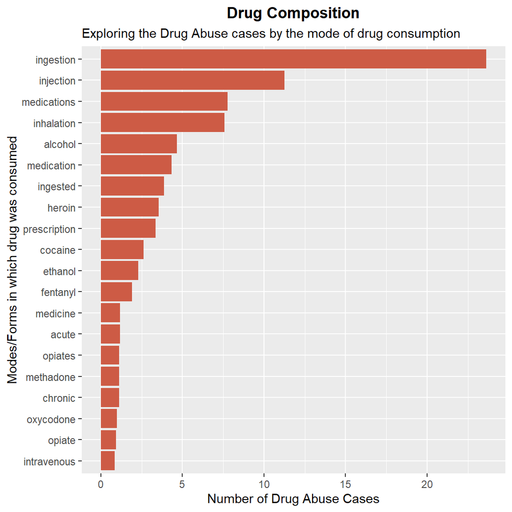

```r
stop_word_list = c('use','and', 'used', 'took', 'multiple', 'of', 'with', 'combined', 'misuse','including', 'consumed','in', 'abused', 'abuse','another', 'while','unknown', 'to','effects','usage','own', 'others','drank', 'substance', 'drug')

remove_stop_words <- function(df){
  filter_df <-  df[!(df$Injury %in% stop_word_list),]
  return (filter_df)
}
all_injury <- c()

for (row in 1:nrow(df_rca)) {
  val = as.character(df_rca[row, "DescriptionofInjury"])
  split_val <- unlist(strsplit(val, ' '))
  all_injury <- c(all_injury, split_val)
}
all_injury <- tolower(all_injury)
temp_df <- data.frame('Injury'=all_injury)
temp_df <- temp_df %>% group_by(Injury) %>% summarise(Freq = n())

temp_df <- na.omit(temp_df)
temp_df <- as.data.frame(temp_df)

# stop word removal
temp_df <- remove_stop_words(temp_df)
total = sum(temp_df$Freq)
temp_df$Freq <- (temp_df$Freq)*100/total
df_word_cloud = temp_df

#temp_df <- temp_df[temp_df$Freq>1,]
temp_df <- temp_df[order(temp_df[,'Freq'] ),]

# plotting the top 20 major modes discovered
temp_df <- tail(temp_df, 20)
ggplot(temp_df, aes(x = reorder(Injury, Freq), y=Freq)) +
  geom_histogram(stat="identity", fill = "coral3") +
  coord_flip() +
  ggtitle("Drug Composition",
          subtitle = "Exploring the Drug Abuse cases by the mode of drug consumption") +
  labs(x = "Modes/Forms in which drug was consumed", y = "Number of Drug Abuse Cases") +
  theme(plot.title = element_text(face = "bold"))  +
  theme(plot.caption = element_text(color = "grey68"))+
  theme(plot.title = element_text(hjust = 0.5))
```

Further we are building the word cloud of the description of injuries.

[figure not shown]

```r
# WordCloud of Injury Description
set.seed(1234)
wordcloud(words = df_word_cloud$Injury, freq = temp_df$Freq, min.freq = 1,
          max.words=500, random.order=FALSE, rot.per=0.35,
          colors=brewer.pal(8, "Dark2"))
```

# Conclusion and Summary

[2] https://www.pewresearch.org/fact-tank/2018/05/30/as-fatal-overdoses-rise-many-americans-see-drug-addiction-as-a-major-problem-in-their-community/

[3] https://portal.ct.gov/DPH/Health-Education-Management--Surveillance/The-Office-of-Injury-Prevention/Opioids-and-Prescription-Drug-Overdose-Prevention-Program